# Fuentes: Datos oficiales COVID19 España

Ricardo Alberich, Juan Gabriel Gomila y Arnau Mir

17/4/2020

# Datos oficiales del Ministerio de Sanidad de España

Ponemos aquí distintos enlaces a los dartos y estadísticas oficiales de Ministerio de Sanidad de España

- [ALERTAS EN SALUD PÚBLICA DE ACTUALIDAD](https://www.mscbs.gob.es/profesionales/saludPublica/ccayes/alertasActual/alertActu.htm)
- [Situación Actual](https://www.mscbs.gob.es/profesionales/saludPublica/ccayes/alertasActual/nCov-China/home.htm)

Desde esta última página podemos acceder a:

- [Informe de situación actual](https://covid19.isciii.es/)
- [Datos causas de muerte MoMo](https://www.isciii.es/QueHacemos/Servicios/VigilanciaSaludPublicaRENAVE/EnfermedadesTransmisibles/MoMo/Paginas/Informes-MoMo-2020.aspx)

## Recopilación de los datos oficiales

La web [Datadista](https://datadista.com/) ha creado un github con los datos oficiales recopilados y con muchos datos más.

Podéis clonar todo el repositorio (contiene muchos más datos) o solo los datos del COVID19 desde

[Datadista github COVID19](https://github.com/datadista)

## Un primer ejemplo: carga de datos desde dos fuentes

En este primer ejemplo hemos descargado de Datadista `ccaa_camas_uci_2017.csv` que contiene datos de 2017 de las camas de UCI por Comunidad Autónoma

```r
CCAA_camas_UCI=read_csv("data/COVID_19_Datadista/COVID19/ccaa_camas_uci_2017.csv")
glimpse(CCAA_camas_UCI)
```

```
## Rows: 17
## Columns: 5
## $ cod_ine  <chr> "01", "02", "03", "15", "05", "06", "07", "08", "09", "10"...
## $ CCAA     <chr> "ANDALUCÍA", "ARAGÓN", "ASTURIAS", "C. FORAL DE NAVARRA", ...
## $ Públicos <dbl> 572, 113, 86, 46, 187, 40, 180, 155, 511, 450, 97, 215, 78...
## $ Privados <dbl> 162, 22, 7, 19, 50, 0, 20, 13, 141, 101, 5, 48, 46, 5, 225...
## $ Total    <dbl> 734, 135, 93, 65, 237, 40, 200, 168, 652, 551, 102, 263, 1...
```

```r
knitr::kable(CCAA_camas_UCI)
```

| cod_ine | CCAA | Públicos | Privados | Total |
| --- | --- | --- | --- | --- |
| 01 | ANDALUCÍA | 572 | 162 | 734 |
| 02 | ARAGÓN | 113 | 22 | 135 |
| 03 | ASTURIAS | 86 | 7 | 93 |
| 15 | C. FORAL DE NAVARRA | 46 | 19 | 65 |
| 05 | CANARIAS | 187 | 50 | 237 |
| 06 | CANTABRIA | 40 | 0 | 40 |
| 07 | CASTILLA Y LEÓN | 180 | 20 | 200 |
| 08 | CASTILLA-LA MANCHA | 155 | 13 | 168 |
| 09 | CATALUÑA | 511 | 141 | 652 |
| 10 | COMUNIDAD VALENCIANA | 450 | 101 | 551 |
| 11 | EXTREMADURA | 97 | 5 | 102 |
| 12 | GALICIA | 215 | 48 | 263 |
| 04 | ILLES BALEARS | 78 | 46 | 124 |
| 21 | LA RIOJA-CEUTA-MELILLA | 29 | 5 | 34 |
| 13 | MADRID | 479 | 225 | 704 |
| 16 | PAÍS VASCO | 158 | 21 | 179 |
| 14 | REGIÓN DE MURCIA | 112 | 11 | 123 |

Ahora queremos el porcentaje de camas UCI por población en España y queremos que este añadido sea de producción propia y con datos oficiales en este caso acudiremos al [Instituto Nacional de Estadística de España (INE)](https://www.ine.es).

Desde aquí buscaremos [Población por comunidades y ciudades autónomas y sexo](https://www.ine.es/jaxiT3/Tabla.htm?t=2853). y nos bajaremos los datos que deseemos ( los guardamos en DatosINE)

```r
poblacion_CCAA_long=read_tsv("data/DataINE_España/Poblacion_CCAA_2017_2019_2853.csv")
glimpse(poblacion_CCAA_long)
```

```
## Rows: 1,440
## Columns: 4
## $ `Comunidades y Ciudades Autónomas` <chr> "Total", "Total", "Total", "Tota...
## $ Sexo                               <chr> "Total", "Total", "Total", "Tota...
## $ Periodo                            <dbl> 2019, 2018, 2017, 2016, 2015, 20...
## $ Total                              <chr> "47.026.208", "46.722.980", "46....
```

```r
knitr::kable(poblacion_CCAA_long)
```

| Comunidades y Ciudades Autónomas | Sexo | Periodo | Total |
| --- | --- | --- | --- |
| Total | Total | 2019 | 47.026.208 |
| Total | Total | 2018 | 46.722.980 |
| Total | Total | 2017 | 46.572.132 |
| Total | Total | 2016 | 46.557.008 |
| Total | Total | 2015 | 46.624.382 |
| Total | Total | 2014 | 46.771.341 |
| Total | Total | 2013 | 47.129.783 |
| Total | Total | 2012 | 47.265.321 |
| Total | Total | 2011 | 47.190.493 |
| Total | Total | 2010 | 47.021.031 |
| Total | Total | 2009 | 46.745.807 |
| Total | Total | 2008 | 46.157.822 |
| Total | Total | 2007 | 45.200.737 |
| Total | Total | 2006 | 44.708.964 |
| Total | Total | 2005 | 44.108.530 |
| Total | Total | 2004 | 43.197.684 |
| Total | Total | 2003 | 42.717.064 |
| Total | Total | 2002 | 41.837.894 |
| Total | Total | 2001 | 41.116.842 |
| Total | Total | 2000 | 40.499.791 |
| Total | Total | 1999 | 40.202.160 |
| Total | Total | 1998 | 39.852.651 |
| Total | Total | 1997 | NA |
| Total | Total | 1996 | 39.669.394 |
| Total | Hombres | 2019 | 23.042.428 |
| Total | Hombres | 2018 | 22.896.602 |
| Total | Hombres | 2017 | 22.832.861 |
| Total | Hombres | 2016 | 22.843.610 |
| Total | Hombres | 2015 | 22.890.383 |
| Total | Hombres | 2014 | 22.985.676 |

[output cut: 1410 more lines]

```r
poblacion_CCAA_wider=poblacion_CCAA_long %>% tidyr::pivot_wider(names_from=Periodo, values_from=Total)
glimpse(poblacion_CCAA_wider)
```

```
## Rows: 60
## Columns: 26
## $ `Comunidades y Ciudades Autónomas` <chr> "Total", "Total", "Total", "01 A...
## $ Sexo                               <chr> "Total", "Hombres", "Mujeres", "...
## $ `2019`                             <chr> "47.026.208", "23.042.428", "23....
## $ `2018`                             <chr> "46.722.980", "22.896.602", "23....
## $ `2017`                             <chr> "46.572.132", "22.832.861", "23....
## $ `2016`                             <chr> "46.557.008", "22.843.610", "23....
## $ `2015`                             <chr> "46.624.382", "22.890.383", "23....
## $ `2014`                             <chr> "46.771.341", "22.985.676", "23....
## $ `2013`                             <chr> "47.129.783", "23.196.386", "23....
## $ `2012`                             <chr> "47.265.321", "23.298.356", "23....
## $ `2011`                             <chr> "47.190.493", "23.283.187", "23....
## $ `2010`                             <chr> "47.021.031", "23.226.185", "23....
## $ `2009`                             <chr> "46.745.807", "23.116.988", "23....
## $ `2008`                             <chr> "46.157.822", "22.847.737", "23....
## $ `2007`                             <chr> "45.200.737", "22.339.962", "22....
## $ `2006`                             <chr> "44.708.964", "22.100.466", "22....
## $ `2005`                             <chr> "44.108.530", "21.780.869", "22....
## $ `2004`                             <chr> "43.197.684", "21.285.247", "21....
## $ `2003`                             <chr> "42.717.064", "21.034.326", "21....
## $ `2002`                             <chr> "41.837.894", "20.564.089", "21....
## $ `2001`                             <chr> "41.116.842", "20.165.514", "20....
## $ `2000`                             <chr> "40.499.791", "19.821.384", "20....
## $ `1999`                             <chr> "40.202.160", "19.670.642", "20....
## $ `1998`                             <chr> "39.852.651", "19.488.465", "20....
## $ `1997`                             <chr> NA, NA, NA, NA, NA, NA, NA, NA, ...
## $ `1996`                             <chr> "39.669.394", "19.399.549", "20....
```

Nos queda una cos notad que las cifras de población han quedado con datos en miles y se han leído no cómo caracter. Tenemos que transforma esa variable. Lo haremos el el fichero long y luego haremos en el wider

### Las funciones `pivot_wider` y `pivot_long`

Probaremos estas funciones con los fichero de datos de altas

#### El fichero de altas por fecha y comunidad autónoma

Fichero largo `ccaa_covid19_altas_long.csv` es una tabla de 4 columnas

- `fecha` : La fecha de la observación tomada de la clase `date`
- `cod_ine`: Es el código de comunidad autónoma del [Instituto Nacional de Estadística](https://www.ine.es/daco/daco42/codmun/cod_ccaa.htm)
- `CCAA` : es el nombre de la comunidad autónoma.
- `total` : La observación para `fecha` del número de altas de esa `CCAA`.

```r
ccaa_altas_long=read_csv("data/COVID_19_Datadista/COVID19/ccaa_covid19_altas_long.csv")
glimpse(ccaa_altas_long)
```

```
## Rows: 620
## Columns: 4
## $ fecha   <date> 2020-03-16, 2020-03-17, 2020-03-18, 2020-03-19, 2020-03-20...
## $ cod_ine <chr> "01", "01", "01", "01", "01", "01", "01", "01", "01", "01",...
## $ CCAA    <chr> "Andalucía", "Andalucía", "Andalucía", "Andalucía", "Andalu...
## $ total   <dbl> 0, 0, 38, 33, 72, 72, 38, 50, 66, 71, 77, 92, 139, 148, 155...
```

```r
knitr::kable(ccaa_altas_long)
```

| fecha | cod_ine | CCAA | total |
| --- | --- | --- | --- |
| 2020-03-16 | 01 | Andalucía | 0 |
| 2020-03-17 | 01 | Andalucía | 0 |
| 2020-03-18 | 01 | Andalucía | 38 |
| 2020-03-19 | 01 | Andalucía | 33 |
| 2020-03-20 | 01 | Andalucía | 72 |
| 2020-03-21 | 01 | Andalucía | 72 |
| 2020-03-22 | 01 | Andalucía | 38 |
| 2020-03-23 | 01 | Andalucía | 50 |
| 2020-03-24 | 01 | Andalucía | 66 |
| 2020-03-25 | 01 | Andalucía | 71 |
| 2020-03-26 | 01 | Andalucía | 77 |
| 2020-03-27 | 01 | Andalucía | 92 |
| 2020-03-28 | 01 | Andalucía | 139 |
| 2020-03-29 | 01 | Andalucía | 148 |
| 2020-03-30 | 01 | Andalucía | 155 |
| 2020-03-31 | 01 | Andalucía | 160 |
| 2020-04-01 | 01 | Andalucía | 182 |
| 2020-04-02 | 01 | Andalucía | 228 |
| 2020-04-03 | 01 | Andalucía | 258 |
| 2020-04-04 | 01 | Andalucía | 463 |
| 2020-04-05 | 01 | Andalucía | 665 |
| 2020-04-06 | 01 | Andalucía | 798 |
| 2020-04-07 | 01 | Andalucía | 900 |
| 2020-04-08 | 01 | Andalucía | 1041 |
| 2020-04-09 | 01 | Andalucía | 1193 |
| 2020-04-10 | 01 | Andalucía | 1437 |
| 2020-04-11 | 01 | Andalucía | 1630 |
| 2020-04-12 | 01 | Andalucía | 1838 |
| 2020-04-13 | 01 | Andalucía | 1967 |
| 2020-04-14 | 01 | Andalucía | 2032 |

[output cut: 590 more lines]

Estos datos los podemos transformar en una tabla con la función `pivot_wider`de la librería `tidyr`

```r
aux1=ccaa_altas_long %>% tidyr::pivot_wider(names_from=fecha,values_from=total)
glimpse(aux1)
```

```
## Rows: 20
## Columns: 33
## $ cod_ine      <chr> "01", "02", "03", "04", "05", "06", "08", "07", "09", ...
## $ CCAA         <chr> "Andalucía", "Aragón", "Asturias", "Baleares", "Canari...
## $ `2020-03-16` <dbl> 0, 0, 3, 1, 7, 10, 12, 5, 0, 0, 2, 4, 4, 474, 0, 1, 0,...
## $ `2020-03-17` <dbl> 0, 0, 3, 1, 8, 10, 12, 5, 0, 0, 12, 5, 7, 951, 0, 1, 0...
## $ `2020-03-18` <dbl> 38, 0, 4, 4, 8, 10, 15, 5, 0, 0, 16, 6, 7, 951, 0, 1, ...
## $ `2020-03-19` <dbl> 33, 0, 4, 6, 9, 10, 27, 27, 0, 0, 19, 6, 4, 941, 0, 1,...
## $ `2020-03-20` <dbl> 72, 0, 12, 10, 6, 10, 34, 37, 150, 0, 20, 7, 5, 1186, ...
## $ `2020-03-21` <dbl> 72, 0, 16, 11, 7, 11, 38, 54, 150, 0, 25, 8, 6, 1542, ...
## $ `2020-03-22` <dbl> 38, 3, 20, 17, 7, 11, 48, 89, 150, 0, 30, 8, 16, 1899,...
## $ `2020-03-23` <dbl> 50, 3, 21, 18, 7, 11, 51, 117, 644, 0, 36, 6, 19, 2063...
## $ `2020-03-24` <dbl> 66, 3, 30, 19, 8, 12, 53, 140, 728, 0, 37, 8, 19, 2291...
## $ `2020-03-25` <dbl> 71, 4, 35, 28, 15, 12, 71, 213, 1274, 0, 44, 8, 25, 30...
## $ `2020-03-26` <dbl> 77, 4, 40, 39, 18, 14, 95, 308, 1697, 0, 57, 24, 47, 3...
```

[output cut: 20 more lines]

```r
knitr::kable(aux1)
```

| cod_ine | CCAA | 2020-03-16 | 2020-03-17 | 2020-03-18 | 2020-03-19 | 2020-03-20 | 2020-03-21 | 2020-03-22 | 2020-03-23 | 2020-03-24 | 2020-03-25 | 2020-03-26 | 2020-03-27 | 2020-03-28 | 2020-03-29 | 2020-03-30 | 2020-03-31 | 2020-04-01 | 2020-04-02 | 2020-04-03 | 2020-04-04 | 2020-04-05 | 2020-04-06 | 2020-04-07 | 2020-04-08 | 2020-04-09 | 2020-04-10 | 2020-04-11 | 2020-04-12 | … |
| --- | --- | --- | --- | --- | --- | --- | --- | --- | --- | --- | --- | --- | --- | --- | --- | --- | --- | --- | --- | --- | --- | --- | --- | --- | --- | --- | --- | --- | --- | --- |
| 01 | Andalucía | 0 | 0 | 38 | 33 | 72 | 72 | 38 | 50 | 66 | 71 | 77 | 92 | 139 | 148 | 155 | 160 | 182 | 228 | 258 | 463 | 665 | 798 | 900 | 1041 | 1193 | 1437 | 1630 | 1838 | … |
| 02 | Aragón | 0 | 0 | 0 | 0 | 0 | 0 | 3 | 3 | 3 | 4 | 4 | 8 | 8 | 8 | 174 | 204 | 257 | 320 | 378 | 440 | 537 | 565 | 578 | 659 | 718 | 797 | 888 | 934 | … |
| 03 | Asturias | 3 | 3 | 4 | 4 | 12 | 16 | 20 | 21 | 30 | 35 | 40 | 52 | 65 | 76 | 78 | 90 | 109 | 135 | 154 | 190 | 216 | 222 | 244 | 294 | 340 | 372 | 414 | 430 | … |
| 04 | Baleares | 1 | 1 | 4 | 6 | 10 | 11 | 17 | 18 | 19 | 28 | 39 | 67 | 80 | 82 | 100 | 111 | 170 | 239 | 375 | 422 | 461 | 531 | 537 | 616 | 696 | 737 | 757 | 848 | … |
| 05 | Canarias | 7 | 8 | 8 | 9 | 6 | 7 | 7 | 7 | 8 | 15 | 18 | 20 | 25 | 30 | 32 | 57 | 77 | 94 | 102 | 123 | 137 | 157 | 186 | 249 | 359 | 386 | 432 | 447 | … |
| 06 | Cantabria | 10 | 10 | 10 | 10 | 10 | 11 | 11 | 11 | 12 | 12 | 14 | 19 | 21 | 25 | 24 | 35 | 43 | 60 | 74 | 99 | 113 | 118 | 129 | 175 | 214 | 265 | 281 | 297 | … |
| 08 | Castilla-La Mancha | 12 | 12 | 15 | 27 | 34 | 38 | 48 | 51 | 53 | 71 | 95 | 153 | 197 | 236 | 252 | 296 | 397 | 494 | 579 | 657 | 1149 | 1259 | 1353 | 1557 | 1766 | 1982 | 2205 | 2365 | … |
| 07 | Castilla y León | 5 | 5 | 5 | 27 | 37 | 54 | 89 | 117 | 140 | 213 | 308 | 423 | 585 | 752 | 871 | 1028 | 1259 | 1498 | 1759 | 2021 | 2331 | 2533 | 2711 | 2988 | 3242 | 3506 | 3757 | 4010 | … |
| 09 | Cataluña | 0 | 0 | 0 | 0 | 150 | 150 | 150 | 644 | 728 | 1274 | 1697 | 2348 | 3106 | 3455 | 4125 | 4966 | 5701 | 6917 | 7849 | 8635 | 9528 | 10088 | 10738 | 12250 | 13063 | 13513 | 14258 | 14975 | … |
| 18 | Ceuta | 0 | 0 | 0 | 0 | 0 | 0 | 0 | 0 | 0 | 0 | 0 | 0 | 0 | 0 | 0 | 0 | 0 | 0 | 2 | 2 | 2 | 2 | 2 | 7 | 7 | 12 | 17 | 17 | … |
| 10 | C. Valenciana | 2 | 12 | 16 | 19 | 20 | 25 | 30 | 36 | 37 | 44 | 57 | 73 | 92 | 161 | 185 | 200 | 240 | 432 | 592 | 695 | 812 | 930 | 1103 | 1344 | 1772 | 2085 | 2289 | 2624 | … |
| 11 | Extremadura | 4 | 5 | 6 | 6 | 7 | 8 | 8 | 6 | 8 | 8 | 24 | 33 | 49 | 51 | 60 | 91 | 113 | 139 | 164 | 205 | 215 | 223 | 282 | 328 | 381 | 397 | 462 | 481 | … |
| 12 | Galicia | 4 | 7 | 7 | 4 | 5 | 6 | 16 | 19 | 19 | 25 | 47 | 67 | 95 | 153 | 168 | 187 | 259 | 333 | 435 | 531 | 587 | 610 | 688 | 800 | 910 | 997 | 1082 | 1143 | … |
| 13 | Madrid | 474 | 951 | 951 | 941 | 1186 | 1542 | 1899 | 2063 | 2291 | 3031 | 3882 | 5044 | 6326 | 7491 | 8301 | 9330 | 10827 | 12400 | 13850 | 15362 | 16543 | 17322 | 18410 | 19836 | 21121 | 22414 | 23663 | 24683 | … |
| 19 | Melilla | 0 | 0 | 0 | 0 | 0 | 0 | 0 | 0 | 0 | 0 | 0 | 0 | 0 | 0 | 0 | 0 | 0 | 0 | 4 | 9 | 11 | 11 | 11 | 12 | 16 | 17 | 18 | 18 | … |
| 14 | Murcia | 1 | 1 | 1 | 1 | 1 | 1 | 1 | 1 | 1 | 4 | 9 | 12 | 12 | 16 | 17 | 20 | 43 | 45 | 90 | 113 | 130 | 156 | 193 | 203 | 219 | 255 | 275 | 344 | … |
| 15 | Navarra | 0 | 0 | 0 | 0 | 1 | 1 | 4 | 7 | 11 | 23 | 35 | 70 | 98 | 125 | 161 | 192 | 236 | 278 | 294 | 311 | 334 | 380 | 421 | 450 | 462 | 560 | 603 | 650 | … |
| 16 | País Vasco | 5 | 11 | 14 | 18 | 21 | 165 | 216 | 283 | 344 | 466 | 621 | 814 | 1023 | 1503 | 1646 | 1796 | 2165 | 2490 | 2809 | 3098 | 3405 | 3568 | 3728 | 4151 | 4514 | 4680 | 4741 | 4867 | … |
| 17 | La Rioja | 2 | 2 | 2 | 2 | 13 | 18 | 18 | 18 | 24 | 43 | 48 | 62 | 364 | 397 | 431 | 496 | 569 | 641 | 745 | 843 | 904 | 964 | 994 | 1061 | 1172 | 1256 | 1337 | 1420 | … |
| 00 | Total | 530 | 1028 | 1081 | 1107 | 1585 | 2125 | 2575 | 3355 | 3794 | 5367 | 7015 | 9357 | 12285 | 14709 | 16780 | 19259 | 22647 | 26743 | 30513 | 34219 | 38080 | 40437 | 43208 | 48021 | 52165 | 55668 | 59109 | 62391 | … |

### Los datos de casos por día y por comunidad autónoma

Fichero `ccaa_covid19_casos.csv` es un fichero que puede ser procesado desde el fichero `ccaa_covid19_casos_long.csv`

- La variable `cod_ine` es el código de comunidad autónoma del [Instituto Nacional de Estadística](https://www.ine.es/daco/daco42/codmun/cod_ccaa.htm).
- La variable `CCAA` es el nombre de la comunidad autónoma.
- El resto de columnas de observación en el tiempo de los casos de enfermos por coronavirus.

```r
ccaa_casos_wider=read_csv("data/COVID_19_Datadista/COVID19/ccaa_covid19_casos.csv")
glimpse(ccaa_casos_wider)
```

```
## Rows: 20
## Columns: 51
## $ cod_ine      <chr> "01", "02", "03", "04", "05", "06", "08", "07", "09", ...
## $ CCAA         <chr> "Andalucía", "Aragón", "Asturias", "Baleares", "Canari...
## $ `2020-02-27` <dbl> 1, 0, 0, 1, 6, 0, 0, 0, 2, 0, 2, 0, 0, 4, 0, 0, 0, 0, ...
## $ `2020-02-28` <dbl> 6, 1, 0, 1, 6, 0, 0, 2, 3, 0, 8, 0, 0, 5, 0, 0, 0, 0, ...
## $ `2020-02-29` <dbl> 8, 1, 0, 2, 6, 0, 0, 2, 5, 0, 10, 0, 0, 8, 0, 0, 0, 2,...
## $ `2020-03-01` <dbl> 12, 0, 1, 2, 7, 1, 1, 3, 6, 0, 15, 4, 0, 10, 0, 0, 1, ...
## $ `2020-03-02` <dbl> 12, 0, 1, 2, 7, 10, 3, 3, 15, 0, 15, 6, 0, 29, 0, 0, 1...
## $ `2020-03-03` <dbl> 13, 0, 1, 2, 7, 10, 7, 8, 15, 0, 15, 6, 0, 49, 0, 0, 1...
## $ `2020-03-04` <dbl> 13, 0, 2, 5, 7, 10, 12, 11, 15, 0, 19, 6, 1, 70, 0, 0,...
## $ `2020-03-05` <dbl> 12, 1, 5, 6, 8, 10, 13, 11, 24, 0, 19, 6, 1, 90, 0, 0,...
## $ `2020-03-06` <dbl> 21, 6, 5, 6, 11, 10, 15, 14, 24, 0, 30, 6, 3, 137, 0, ...
## $ `2020-03-07` <dbl> 27, 11, 5, 6, 18, 10, 15, 14, 24, 0, 30, 6, 3, 174, 0,...
## $ `2020-03-08` <dbl> 35, 13, 7, 8, 17, 12, 15, 22, 49, 0, 37, 6, 5, 202, 0,...
```

[output cut: 38 more lines]

```r
knitr::kable(ccaa_casos_wider)
```

| cod_ine | CCAA | 2020-02-27 | 2020-02-28 | 2020-02-29 | 2020-03-01 | 2020-03-02 | 2020-03-03 | 2020-03-04 | 2020-03-05 | 2020-03-06 | 2020-03-07 | 2020-03-08 | 2020-03-09 | 2020-03-10 | 2020-03-11 | 2020-03-12 | 2020-03-13 | 2020-03-14 | 2020-03-15 | 2020-03-16 | 2020-03-17 | 2020-03-18 | 2020-03-19 | 2020-03-20 | 2020-03-21 | 2020-03-22 | 2020-03-23 | 2020-03-24 | 2020-03-25 | … |
| --- | --- | --- | --- | --- | --- | --- | --- | --- | --- | --- | --- | --- | --- | --- | --- | --- | --- | --- | --- | --- | --- | --- | --- | --- | --- | --- | --- | --- | --- | --- |
| 01 | Andalucía | 1 | 6 | 8 | 12 | 12 | 13 | 13 | 12 | 21 | 27 | 35 | 54 | 71 | 90 | 115 | 219 | 269 | 437 | 554 | 683 | 859 | 1008 | 1287 | 1515 | 1725 | 1961 | 2471 | 3010 | … |
| 02 | Aragón | 0 | 1 | 1 | 0 | 0 | 0 | 0 | 1 | 6 | 11 | 13 | 13 | 38 | 45 | 64 | 80 | 80 | 147 | 174 | 207 | 226 | 281 | 360 | 424 | 532 | 638 | 758 | 907 | … |
| 03 | Asturias | 0 | 0 | 0 | 1 | 1 | 1 | 2 | 5 | 5 | 5 | 7 | 7 | 22 | 32 | 47 | 67 | 92 | 137 | 177 | 193 | 242 | 292 | 344 | 486 | 545 | 594 | 662 | 779 | … |
| 04 | Baleares | 1 | 1 | 2 | 2 | 2 | 2 | 5 | 6 | 6 | 6 | 8 | 11 | 13 | 16 | 22 | 30 | 28 | 28 | 73 | 92 | 112 | 169 | 203 | 246 | 331 | 400 | 478 | 562 | … |
| 05 | Canarias | 6 | 6 | 6 | 7 | 7 | 7 | 7 | 8 | 11 | 18 | 17 | 22 | 25 | 37 | 51 | 70 | 90 | 109 | 119 | 148 | 181 | 220 | 287 | 348 | 414 | 481 | 557 | 657 | … |
| 06 | Cantabria | 0 | 0 | 0 | 1 | 10 | 10 | 10 | 10 | 10 | 10 | 12 | 12 | 12 | 12 | 16 | 29 | 31 | 51 | 58 | 58 | 68 | 83 | 144 | 215 | 282 | 347 | 425 | 510 | … |
| 08 | Castilla-La Mancha | 0 | 0 | 0 | 1 | 3 | 7 | 12 | 13 | 15 | 15 | 15 | 26 | 39 | 71 | 115 | 194 | 289 | 401 | 567 | 567 | 675 | 801 | 1044 | 1423 | 1819 | 2078 | 2465 | 2780 | … |
| 07 | Castilla y León | 0 | 2 | 2 | 3 | 3 | 8 | 11 | 11 | 14 | 14 | 22 | 23 | 56 | 71 | 92 | 169 | 223 | 292 | 334 | 431 | 668 | 868 | 1147 | 1466 | 1744 | 2055 | 2460 | 2940 | … |
| 09 | Cataluña | 2 | 3 | 5 | 6 | 15 | 15 | 15 | 24 | 24 | 24 | 49 | 75 | 124 | 156 | 260 | 316 | 509 | 715 | 903 | 1394 | 1866 | 2702 | 3270 | 4203 | 4704 | 5925 | 7864 | 9937 | … |
| 18 | Ceuta | 0 | 0 | 0 | 0 | 0 | 0 | 0 | 0 | 0 | 0 | 0 | 0 | 0 | 0 | 0 | 0 | 0 | 1 | 1 | 1 | 1 | 1 | 5 | 5 | 5 | 6 | 6 | 9 | … |
| 10 | C. Valenciana | 2 | 8 | 10 | 15 | 15 | 15 | 19 | 19 | 30 | 30 | 37 | 37 | 50 | 65 | 76 | 94 | 130 | 409 | 409 | 541 | 726 | 921 | 1105 | 1363 | 1604 | 1901 | 2167 | 2616 | … |
| 11 | Extremadura | 0 | 0 | 0 | 4 | 6 | 6 | 6 | 6 | 6 | 6 | 6 | 7 | 8 | 9 | 19 | 39 | 66 | 95 | 111 | 153 | 194 | 241 | 297 | 354 | 384 | 493 | 636 | 742 | … |
| 12 | Galicia | 0 | 0 | 0 | 0 | 0 | 0 | 1 | 1 | 3 | 3 | 5 | 6 | 22 | 39 | 35 | 85 | 115 | 195 | 245 | 292 | 341 | 453 | 578 | 739 | 915 | 1208 | 1415 | 1653 | … |
| 13 | Madrid | 4 | 5 | 8 | 10 | 29 | 49 | 70 | 90 | 137 | 174 | 202 | 469 | 782 | 1024 | 1388 | 1990 | 2940 | 3544 | 4165 | 4871 | 5637 | 6777 | 7165 | 8921 | 9702 | 10575 | 12352 | 14597 | … |
| 19 | Melilla | 0 | 0 | 0 | 0 | 0 | 0 | 0 | 0 | 0 | 0 | 0 | 0 | 0 | 0 | 0 | 2 | 3 | 8 | 8 | 17 | 20 | 23 | 24 | 25 | 25 | 28 | 28 | 38 | … |
| 14 | Murcia | 0 | 0 | 0 | 0 | 0 | 0 | 0 | 0 | 0 | 0 | 1 | 4 | 9 | 11 | 26 | 35 | 47 | 71 | 77 | 97 | 122 | 167 | 204 | 240 | 296 | 345 | 385 | 477 | … |
| 15 | Navarra | 0 | 0 | 0 | 1 | 1 | 1 | 3 | 3 | 3 | 3 | 3 | 3 | 12 | 46 | 73 | 130 | 146 | 183 | 274 | 313 | 386 | 482 | 554 | 664 | 794 | 886 | 1014 | 1197 | … |
| 16 | País Vasco | 0 | 0 | 2 | 3 | 9 | 13 | 17 | 17 | 45 | 45 | 102 | 149 | 195 | 225 | 346 | 417 | 417 | 630 | 630 | 765 | 973 | 1190 | 1465 | 1725 | 2097 | 2421 | 2728 | 3271 | … |
| 17 | La Rioja | 0 | 0 | 0 | 0 | 1 | 3 | 7 | 11 | 29 | 39 | 55 | 81 | 144 | 179 | 205 | 243 | 278 | 300 | 312 | 355 | 419 | 468 | 497 | 564 | 654 | 747 | 802 | 928 | … |
| 00 | Total | 16 | 32 | 44 | 66 | 114 | 150 | 198 | 237 | 365 | 430 | 589 | 999 | 1622 | 2128 | 2950 | 4209 | 5753 | 7753 | 9191 | 11178 | 13716 | 17147 | 19980 | 24926 | 28572 | 33089 | 39673 | 47610 | … |

Podemos recuperar el fichero largo con la función `pivot_longer`

```r
aux2=ccaa_casos_wider %>% pivot_longer(cols=starts_with("2020"))
glimpse(aux2)
```

```
## Rows: 980
## Columns: 4
## $ cod_ine <chr> "01", "01", "01", "01", "01", "01", "01", "01", "01", "01",...
## $ CCAA    <chr> "Andalucía", "Andalucía", "Andalucía", "Andalucía", "Andalu...
## $ name    <chr> "2020-02-27", "2020-02-28", "2020-02-29", "2020-03-01", "20...
## $ value   <dbl> 1, 6, 8, 12, 12, 13, 13, 12, 21, 27, 35, 54, 71, 90, 115, 2...
```

```r
knitr::kable(aux2)
```

| cod_ine | CCAA | name | value |
| --- | --- | --- | --- |
| 01 | Andalucía | 2020-02-27 | 1 |
| 01 | Andalucía | 2020-02-28 | 6 |
| 01 | Andalucía | 2020-02-29 | 8 |
| 01 | Andalucía | 2020-03-01 | 12 |
| 01 | Andalucía | 2020-03-02 | 12 |
| 01 | Andalucía | 2020-03-03 | 13 |
| 01 | Andalucía | 2020-03-04 | 13 |
| 01 | Andalucía | 2020-03-05 | 12 |
| 01 | Andalucía | 2020-03-06 | 21 |
| 01 | Andalucía | 2020-03-07 | 27 |
| 01 | Andalucía | 2020-03-08 | 35 |
| 01 | Andalucía | 2020-03-09 | 54 |
| 01 | Andalucía | 2020-03-10 | 71 |
| 01 | Andalucía | 2020-03-11 | 90 |
| 01 | Andalucía | 2020-03-12 | 115 |
| 01 | Andalucía | 2020-03-13 | 219 |
| 01 | Andalucía | 2020-03-14 | 269 |
| 01 | Andalucía | 2020-03-15 | 437 |
| 01 | Andalucía | 2020-03-16 | 554 |
| 01 | Andalucía | 2020-03-17 | 683 |
| 01 | Andalucía | 2020-03-18 | 859 |
| 01 | Andalucía | 2020-03-19 | 1008 |
| 01 | Andalucía | 2020-03-20 | 1287 |
| 01 | Andalucía | 2020-03-21 | 1515 |
| 01 | Andalucía | 2020-03-22 | 1725 |
| 01 | Andalucía | 2020-03-23 | 1961 |
| 01 | Andalucía | 2020-03-24 | 2471 |
| 01 | Andalucía | 2020-03-25 | 3010 |
| 01 | Andalucía | 2020-03-26 | 3406 |
| 01 | Andalucía | 2020-03-27 | 3793 |

[output cut: 950 more lines]

## Nuestro modelo de datos

Definamos nuestro modelo de datos Para ello separemos los ficheros de datos en dos grupos

## Metadatos

Son datos relativos a las unidades en las que se miden las variables. Las unidades pueden ser: continentes, países, regiones. Las regiones reciben distintas denominaciones según la organización de cada país: departamentos, estados, comunidades autónomas, **landers** , provincias, etc.

Algunos de los ficheros correspondientes a metadatos son :

- `alojamientos_turisticos_boe_2020_4194.csv`
- `ccaa_camas_uci_2017.csv`
- `ccaa_covid19_mascarillas.csv`
- `municipios_distritos_madrid_casos.csv`
- `nacional_covid19_rango_edad.csv`
- `puntos_restauracion_comida_para_llevar.csv`

## Datos sobre la epidemia

Los datos epidemiológicos son los que e contabilidad datos sobre la pandemia en cada unidad de medida. Como ya hemos explicado están en la versión **wider** la **long**

- Datos de *casos* de pacientes de coronavirus
  - `ccaa_covid19_casos.csv`; `ccaa_covid19_casos_long.csv`
- Datos de *altas* de pacientes de coronavirus
  - `ccaa_covid19_altas.csv`; `ccaa_covid19_altas_long.csv`
- Datos de *fallecidos* de pacientes de coronavirus
  - `ccaa_covid19_fallecidos.csv`; `ccaa_covid19_fallecidos_long.csv`
- Datos de pacientes *hospitalizados* de pacientes de coronavirus
  - `ccaa_covid19_hospitalizados.csv`; `ccaa_covid19_hospitalizados_long.csv`
- Datos de pacientes en *UCI* de pacientes de coronavirus
  - `ccaa_covid19_uci.csv`; `ccaa_covid19_uci_long.csv`

## Tabla base de nuestro modelo de datos

Vamos a construir una tabla de tipo “long” con todos los datos. Para ello apilaremos las tablas long añadiendo la categoría que mide la variable total: casos, ingresos, fallecimientos, uci.

Empecemos con algunas variables auxiliares

```r
tipos=c("casos","hospitalizados","fallecidos","uci","altas")
prefijo="data/COVID_19_Datadista/COVID19/ccaa_covid19_"
sufijo="_long.csv"
arreglo<- function(tipo,prefijo="data/COVID_19_Datadista/COVID19/ccaa_covid19_",sufijo="_long.csv"){
aux=read_csv(paste0(prefijo,tipo,sufijo))
aux$tipo=tipo
return(aux)
}

datos_COVID19_long=bind_rows(lapply(tipos,FUN=arreglo))
datos_COVID19_long
```

| fecha | cod_ine | CCAA | total | tipo |
| --- | --- | --- | --- | --- |
| 2020-02-27 | 01 | Andalucía | 1 | casos |
| 2020-02-28 | 01 | Andalucía | 6 | casos |
| 2020-02-29 | 01 | Andalucía | 8 | casos |
| 2020-03-01 | 01 | Andalucía | 12 | casos |
| 2020-03-02 | 01 | Andalucía | 12 | casos |
| 2020-03-03 | 01 | Andalucía | 13 | casos |
| 2020-03-04 | 01 | Andalucía | 13 | casos |
| 2020-03-05 | 01 | Andalucía | 12 | casos |
| 2020-03-06 | 01 | Andalucía | 21 | casos |
| 2020-03-07 | 01 | Andalucía | 27 | casos |
| 2020-03-08 | 01 | Andalucía | 35 | casos |
| 2020-03-09 | 01 | Andalucía | 54 | casos |
| 2020-03-10 | 01 | Andalucía | 71 | casos |
| 2020-03-11 | 01 | Andalucía | 90 | casos |
| 2020-03-12 | 01 | Andalucía | 115 | casos |
| 2020-03-13 | 01 | Andalucía | 219 | casos |
| 2020-03-14 | 01 | Andalucía | 269 | casos |
| 2020-03-15 | 01 | Andalucía | 437 | casos |
| 2020-03-16 | 01 | Andalucía | 554 | casos |
| 2020-03-17 | 01 | Andalucía | 683 | casos |
| 2020-03-18 | 01 | Andalucía | 859 | casos |
| 2020-03-19 | 01 | Andalucía | 1008 | casos |
| 2020-03-20 | 01 | Andalucía | 1287 | casos |
| 2020-03-21 | 01 | Andalucía | 1515 | casos |
| 2020-03-22 | 01 | Andalucía | 1725 | casos |
| 2020-03-23 | 01 | Andalucía | 1961 | casos |
| 2020-03-24 | 01 | Andalucía | 2471 | casos |
| 2020-03-25 | 01 | Andalucía | 3010 | casos |
| 2020-03-26 | 01 | Andalucía | 3406 | casos |
| 2020-03-27 | 01 | Andalucía | 3793 | casos |

[output cut: 3750 more lines]

## Añadir metadatos a nuestro modelo de datos

Vamos a añadir las poblaciones de cada Comunidad Autónoma y su número de camas de cuidados intensivos (uci).

```r
camas_uci=read_csv("data/COVID_19_Datadista/COVID19/ccaa_camas_uci_2017.csv")
camas_uci %>% rename(Públicos_UCI=Públicos,Privados_UCI=Privados,Total_UCI=Total)
```

| cod_ine | CCAA | Públicos_UCI | Privados_UCI | Total_UCI |
| --- | --- | --- | --- | --- |
| 01 | ANDALUCÍA | 572 | 162 | 734 |
| 02 | ARAGÓN | 113 | 22 | 135 |
| 03 | ASTURIAS | 86 | 7 | 93 |
| 15 | C. FORAL DE NAVARRA | 46 | 19 | 65 |
| 05 | CANARIAS | 187 | 50 | 237 |
| 06 | CANTABRIA | 40 | 0 | 40 |
| 07 | CASTILLA Y LEÓN | 180 | 20 | 200 |
| 08 | CASTILLA-LA MANCHA | 155 | 13 | 168 |
| 09 | CATALUÑA | 511 | 141 | 652 |
| 10 | COMUNIDAD VALENCIANA | 450 | 101 | 551 |
| 11 | EXTREMADURA | 97 | 5 | 102 |
| 12 | GALICIA | 215 | 48 | 263 |
| 04 | ILLES BALEARS | 78 | 46 | 124 |
| 21 | LA RIOJA-CEUTA-MELILLA | 29 | 5 | 34 |
| 13 | MADRID | 479 | 225 | 704 |
| 16 | PAÍS VASCO | 158 | 21 | 179 |
| 14 | REGIÓN DE MURCIA | 112 | 11 | 123 |

```r
knitr::kable(camas_uci)
```

| cod_ine | CCAA | Públicos | Privados | Total |
| --- | --- | --- | --- | --- |
| 01 | ANDALUCÍA | 572 | 162 | 734 |
| 02 | ARAGÓN | 113 | 22 | 135 |
| 03 | ASTURIAS | 86 | 7 | 93 |
| 15 | C. FORAL DE NAVARRA | 46 | 19 | 65 |
| 05 | CANARIAS | 187 | 50 | 237 |
| 06 | CANTABRIA | 40 | 0 | 40 |
| 07 | CASTILLA Y LEÓN | 180 | 20 | 200 |
| 08 | CASTILLA-LA MANCHA | 155 | 13 | 168 |
| 09 | CATALUÑA | 511 | 141 | 652 |
| 10 | COMUNIDAD VALENCIANA | 450 | 101 | 551 |
| 11 | EXTREMADURA | 97 | 5 | 102 |
| 12 | GALICIA | 215 | 48 | 263 |
| 04 | ILLES BALEARS | 78 | 46 | 124 |
| 21 | LA RIOJA-CEUTA-MELILLA | 29 | 5 | 34 |
| 13 | MADRID | 479 | 225 | 704 |
| 16 | PAÍS VASCO | 158 | 21 | 179 |
| 14 | REGIÓN DE MURCIA | 112 | 11 | 123 |

```r
poblacion_CCAA=read_tsv("data/DataINE_España/Poblacion_CCAA_2017_2019_2853.csv",locale = locale(grouping_mark = "."))
poblacion_CCAA= poblacion_CCAA %>%
  filter(`Comunidades y Ciudades Autónomas`!="Total",Sexo=="Total",Periodo==2019) %>%
  transmute(cod_ine=str_sub(`Comunidades y Ciudades Autónomas`,1,2),
    Pob_CCAA_2019=Total,CCAA=`Comunidades y Ciudades Autónomas`)
glimpse(poblacion_CCAA)
```

```
## Rows: 19
## Columns: 3
## $ cod_ine       <chr> "01", "02", "03", "04", "05", "06", "07", "08", "09",...
## $ Pob_CCAA_2019 <dbl> 8414240, 1319291, 1022800, 1149460, 2153389, 581078, ...
## $ CCAA          <chr> "01 Andalucía", "02 Aragón", "03 Asturias, Principado...
```

```r
knitr::kable(poblacion_CCAA)
```

| cod_ine | Pob_CCAA_2019 | CCAA |
| --- | --- | --- |
| 01 | 8414240 | 01 Andalucía |
| 02 | 1319291 | 02 Aragón |
| 03 | 1022800 | 03 Asturias, Principado de |
| 04 | 1149460 | 04 Balears, Illes |
| 05 | 2153389 | 05 Canarias |
| 06 | 581078 | 06 Cantabria |
| 07 | 2399548 | 07 Castilla y León |
| 08 | 2032863 | 08 Castilla - La Mancha |
| 09 | 7675217 | 09 Cataluña |
| 10 | 5003769 | 10 Comunitat Valenciana |
| 11 | 1067710 | 11 Extremadura |
| 12 | 2699499 | 12 Galicia |
| 13 | 6663394 | 13 Madrid, Comunidad de |
| 14 | 1493898 | 14 Murcia, Región de |
| 15 | 654214 | 15 Navarra, Comunidad Foral de |
| 16 | 2207776 | 16 País Vasco |
| 17 | 316798 | 17 Rioja, La |
| 18 | 84777 | 18 Ceuta |
| 19 | 86487 | 19 Melilla |

### Añadimos los metadatos

Podemos construir una tibble que contega toda la información utilizando funciones tipo "inner_join

```r
metadatos_CCAA=  poblacion_CCAA %>% select(-CCAA) %>%
  inner_join(camas_uci,by="cod_ine") %>%
  rename(UCIS_Públicos=Públicos,UCIS_Privados=Privados, UCI_Total=Total)

datos_COVID19_con_metadatos_long= datos_COVID19_long %>% inner_join(metadatos_CCAA %>% select(-CCAA))
```

## Guardamos los datos

Guardaremos los datos como objetos y como cvs

```r
save(datos_COVID19_long,
     file="data/Modelo_Datos/datos_COVID19_long_long.Robj")
save(metadatos_CCAA,
     file="data/Modelo_Datos/metadatos_CCAA.Robj")
save(datos_COVID19_con_metadatos_long,
     file="data/Modelo_Datos/datos_COVID19_con_metadatos_long.Robj")


write_csv(datos_COVID19_long,
          path="data/Modelo_Datos/datos_COVID19_long.csv")
write_csv(metadatos_CCAA,
          path="data/Modelo_Datos/metadatos_CCAA.csv")
write_csv(datos_COVID19_con_metadatos_long,
          path="data/Modelo_Datos/datos_COVID19_con_metadatos_long.csv")
```

### Uso de los datos

```r
data_long=read_csv("data/Modelo_Datos/datos_COVID19_con_metadatos_long.csv")
data_long_filtrado= data_long %>% select(fecha,CCAA,total,tipo)

data_wider_filtrado= data_long_filtrado %>%
  pivot_wider(names_from=CCAA,values_from=total)

knitr::kable(data_wider_filtrado)
```

| fecha | tipo | Andalucía | Aragón | Asturias | Baleares | Canarias | Cantabria | Castilla-La Mancha | Castilla y León | Cataluña | C. Valenciana | Extremadura | Galicia | Madrid | Murcia | Navarra | País Vasco |
| --- | --- | --- | --- | --- | --- | --- | --- | --- | --- | --- | --- | --- | --- | --- | --- | --- | --- |
| 2020-02-27 | casos | 1 | 0 | 0 | 1 | 6 | 0 | 0 | 0 | 2 | 2 | 0 | 0 | 4 | 0 | 0 | 0 |
| 2020-02-28 | casos | 6 | 1 | 0 | 1 | 6 | 0 | 0 | 2 | 3 | 8 | 0 | 0 | 5 | 0 | 0 | 0 |
| 2020-02-29 | casos | 8 | 1 | 0 | 2 | 6 | 0 | 0 | 2 | 5 | 10 | 0 | 0 | 8 | 0 | 0 | 2 |
| 2020-03-01 | casos | 12 | 0 | 1 | 2 | 7 | 1 | 1 | 3 | 6 | 15 | 4 | 0 | 10 | 0 | 1 | 3 |
| 2020-03-02 | casos | 12 | 0 | 1 | 2 | 7 | 10 | 3 | 3 | 15 | 15 | 6 | 0 | 29 | 0 | 1 | 9 |
| 2020-03-03 | casos | 13 | 0 | 1 | 2 | 7 | 10 | 7 | 8 | 15 | 15 | 6 | 0 | 49 | 0 | 1 | 13 |
| 2020-03-04 | casos | 13 | 0 | 2 | 5 | 7 | 10 | 12 | 11 | 15 | 19 | 6 | 1 | 70 | 0 | 3 | 17 |
| 2020-03-05 | casos | 12 | 1 | 5 | 6 | 8 | 10 | 13 | 11 | 24 | 19 | 6 | 1 | 90 | 0 | 3 | 17 |
| 2020-03-06 | casos | 21 | 6 | 5 | 6 | 11 | 10 | 15 | 14 | 24 | 30 | 6 | 3 | 137 | 0 | 3 | 45 |
| 2020-03-07 | casos | 27 | 11 | 5 | 6 | 18 | 10 | 15 | 14 | 24 | 30 | 6 | 3 | 174 | 0 | 3 | 45 |
| 2020-03-08 | casos | 35 | 13 | 7 | 8 | 17 | 12 | 15 | 22 | 49 | 37 | 6 | 5 | 202 | 1 | 3 | 102 |
| 2020-03-09 | casos | 54 | 13 | 7 | 11 | 22 | 12 | 26 | 23 | 75 | 37 | 7 | 6 | 469 | 4 | 3 | 149 |
| 2020-03-10 | casos | 71 | 38 | 22 | 13 | 25 | 12 | 39 | 56 | 124 | 50 | 8 | 22 | 782 | 9 | 12 | 195 |
| 2020-03-11 | casos | 90 | 45 | 32 | 16 | 37 | 12 | 71 | 71 | 156 | 65 | 9 | 39 | 1024 | 11 | 46 | 225 |
| 2020-03-12 | casos | 115 | 64 | 47 | 22 | 51 | 16 | 115 | 92 | 260 | 76 | 19 | 35 | 1388 | 26 | 73 | 346 |
| 2020-03-13 | casos | 219 | 80 | 67 | 30 | 70 | 29 | 194 | 169 | 316 | 94 | 39 | 85 | 1990 | 35 | 130 | 417 |
| 2020-03-14 | casos | 269 | 80 | 92 | 28 | 90 | 31 | 289 | 223 | 509 | 130 | 66 | 115 | 2940 | 47 | 146 | 417 |
| 2020-03-15 | casos | 437 | 147 | 137 | 28 | 109 | 51 | 401 | 292 | 715 | 409 | 95 | 195 | 3544 | 71 | 183 | 630 |
| 2020-03-16 | casos | 554 | 174 | 177 | 73 | 119 | 58 | 567 | 334 | 903 | 409 | 111 | 245 | 4165 | 77 | 274 | 630 |
| 2020-03-17 | casos | 683 | 207 | 193 | 92 | 148 | 58 | 567 | 431 | 1394 | 541 | 153 | 292 | 4871 | 97 | 313 | 765 |
| 2020-03-18 | casos | 859 | 226 | 242 | 112 | 181 | 68 | 675 | 668 | 1866 | 726 | 194 | 341 | 5637 | 122 | 386 | 973 |
| 2020-03-19 | casos | 1008 | 281 | 292 | 169 | 220 | 83 | 801 | 868 | 2702 | 921 | 241 | 453 | 6777 | 167 | 482 | 1190 |
| 2020-03-20 | casos | 1287 | 360 | 344 | 203 | 287 | 144 | 1044 | 1147 | 3270 | 1105 | 297 | 578 | 7165 | 204 | 554 | 1465 |
| 2020-03-21 | casos | 1515 | 424 | 486 | 246 | 348 | 215 | 1423 | 1466 | 4203 | 1363 | 354 | 739 | 8921 | 240 | 664 | 1725 |
| 2020-03-22 | casos | 1725 | 532 | 545 | 331 | 414 | 282 | 1819 | 1744 | 4704 | 1604 | 384 | 915 | 9702 | 296 | 794 | 2097 |
| 2020-03-23 | casos | 1961 | 638 | 594 | 400 | 481 | 347 | 2078 | 2055 | 5925 | 1901 | 493 | 1208 | 10575 | 345 | 886 | 2421 |
| 2020-03-24 | casos | 2471 | 758 | 662 | 478 | 557 | 425 | 2465 | 2460 | 7864 | 2167 | 636 | 1415 | 12352 | 385 | 1014 | 2728 |
| 2020-03-25 | casos | 3010 | 907 | 779 | 562 | 657 | 510 | 2780 | 2940 | 9937 | 2616 | 742 | 1653 | 14597 | 477 | 1197 | 3271 |
| 2020-03-26 | casos | 3406 | 1116 | 841 | 660 | 784 | 671 | 3383 | 3488 | 11592 | 3200 | 969 | 1915 | 17166 | 596 | 1411 | 3946 |
| 2020-03-27 | casos | 3793 | 1338 | 900 | 755 | 878 | 810 | 3934 | 4132 | 12940 | 3532 | 1231 | 2322 | 19243 | 714 | 1641 | 4601 |

[output cut: 159 more lines]

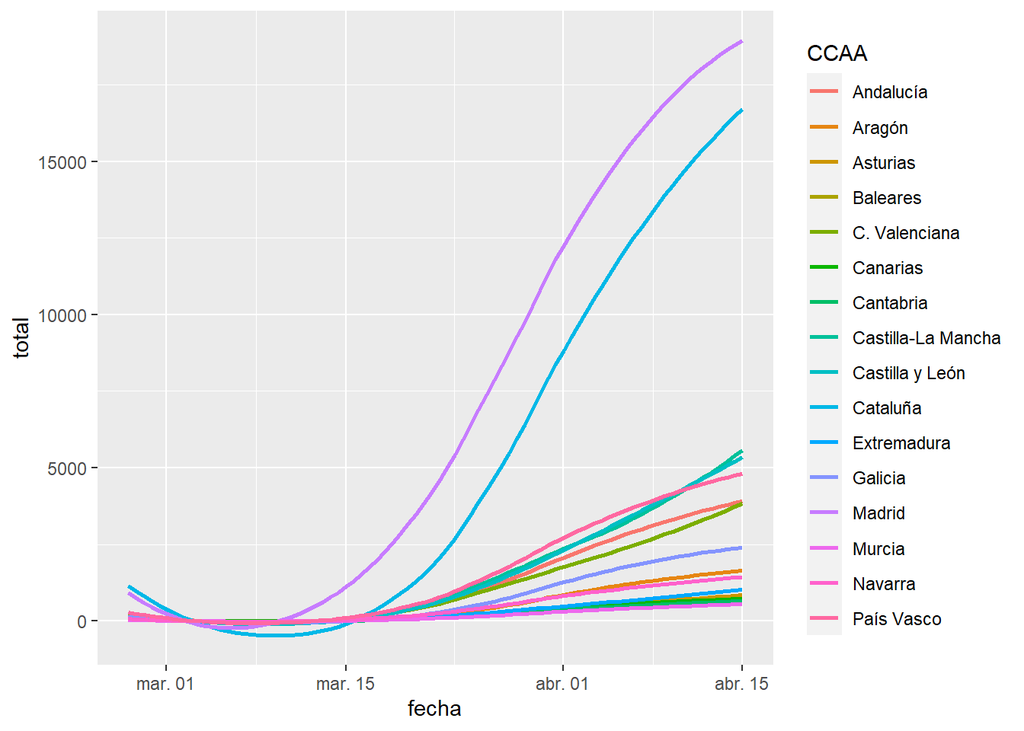

```r
ggplot(data_long_filtrado[-2,],aes(x=fecha,y=total,col=CCAA))+geom_smooth(se = FALSE)
```